# Final Project 2

## The Politics of Mask Use During COVID-19

**Benedicte Knudson, Diego Oldenburg, Alex Abadi** Final Data Science Tutorial CMPS 3160-01 - Introduction to Data Science

[Notebook](https://bknudson1.github.io/)

**Project description and goals** From the very beginning of the pandemic, mask use has been highly politicized. We are interested in finding out the effects of the politicization and seeing if mask use is truly as decisive an issue as the media has made it out to be. To accomplish this, we will attempt to answer the following questions:

1. How does self-reported mask use vary across each county in the United States?
2. How does self-reported mask use in each county in the US correlate with how they voted in the 2020 presidential election?

**Collaboration plan** To begin, we have set up a GitHub repository and a Google colab document that we all have access to where we will store and update our code. We will be meeting weekly as a group and have committed to doing work individually on our own time.

### Extract, Transform, Load

**Data description** The [New York Times](https://github.com/nytimes/covid-19-data) has a number of incredibly robust data sets relating to COVID-19. We will be using specifically their data sets about face mask use and total COVID-19 cases and deaths. (A note about the face mask use data: the data was collected over a period of about two weeks, during July 2020. The data is self reported from around 250,000 people. We understand that self reported data must be taken with a grain of salt.) The data about the 2020 election at the county level has been provided by a GitHub user tonmcg, 2020 election results at the county-level are scraped from results published by from Fox News, Politico, and the New York Times. To help create the the choropleth county maps, we used TIGER/Line Shapefiles provided by Census.gov.

```python
#Importing libraries
from bs4 import BeautifulSoup as bs
import requests as requests
import pandas as pd
import numpy as np
import lxml as lx

import datetime as dt
from datetime import date
from datetime import time

import matplotlib.pyplot as plt
import seaborn as sns
import re
import geopandas as gpd

import sklearn
from sklearn.preprocessing import StandardScaler
from sklearn.neighbors import KNeighborsClassifier

import plotly.express as px
import json
```

```python
#Loading data
mask_df=pd.read_csv("./data/mask-use/mask-use-by-county.csv")
election_df= pd.read_csv("./data/2020_US_County_Level_Presidential_Results.csv")
counties_df=pd.read_csv("./data/us-counties.csv")
counties_map = gpd.read_file('./data/tl_2021_us_county/tl_2021_us_county.shp')
```

```python
mask_df.head()
```

|  | COUNTYFP | NEVER | RARELY | SOMETIMES | FREQUENTLY | ALWAYS |
| --- | --- | --- | --- | --- | --- | --- |
| 0 | 1001 | 0.053 | 0.074 | 0.134 | 0.295 | 0.444 |
| 1 | 1003 | 0.083 | 0.059 | 0.098 | 0.323 | 0.436 |
| 2 | 1005 | 0.067 | 0.121 | 0.120 | 0.201 | 0.491 |
| 3 | 1007 | 0.020 | 0.034 | 0.096 | 0.278 | 0.572 |
| 4 | 1009 | 0.053 | 0.114 | 0.180 | 0.194 | 0.459 |

```python
election_df.head()
```

|  | state_name | county_fips | county_name | votes_gop | votes_dem | total_votes | diff | per_gop | per_dem | per_point_diff |
| --- | --- | --- | --- | --- | --- | --- | --- | --- | --- | --- |
| 0 | Alabama | 1001 | Autauga County | 19838 | 7503 | 27770 | 12335 | 0.714368 | 0.270184 | 0.444184 |
| 1 | Alabama | 1003 | Baldwin County | 83544 | 24578 | 109679 | 58966 | 0.761714 | 0.224090 | 0.537623 |
| 2 | Alabama | 1005 | Barbour County | 5622 | 4816 | 10518 | 806 | 0.534512 | 0.457882 | 0.076631 |
| 3 | Alabama | 1007 | Bibb County | 7525 | 1986 | 9595 | 5539 | 0.784263 | 0.206983 | 0.577280 |
| 4 | Alabama | 1009 | Blount County | 24711 | 2640 | 27588 | 22071 | 0.895716 | 0.095694 | 0.800022 |

```python
counties_df.head()
```

|  | date | county | state | fips | cases | deaths |
| --- | --- | --- | --- | --- | --- | --- |
| 0 | 2020-01-21 | Snohomish | Washington | 53061.0 | 1 | 0.0 |
| 1 | 2020-01-22 | Snohomish | Washington | 53061.0 | 1 | 0.0 |
| 2 | 2020-01-23 | Snohomish | Washington | 53061.0 | 1 | 0.0 |
| 3 | 2020-01-24 | Cook | Illinois | 17031.0 | 1 | 0.0 |
| 4 | 2020-01-24 | Snohomish | Washington | 53061.0 | 1 | 0.0 |

```python
counties_map.head()
```

|  | STATEFP | COUNTYFP | COUNTYNS | GEOID | NAME | NAMELSAD | LSAD | CLASSFP | MTFCC | CSAFP | CBSAFP | METDIVFP | FUNCSTAT | ALAND | AWATER | INTPTLAT | INTPTLON | geometry |
| --- | --- | --- | --- | --- | --- | --- | --- | --- | --- | --- | --- | --- | --- | --- | --- | --- | --- | --- |
| 0 | 31 | 039 | 00835841 | 31039 | Cuming | Cuming County | 06 | H1 | G4020 | None | None | None | A | 1477645345 | 10690204 | +41.9158651 | -096.7885168 | POLYGON ((-96.55515 41.91587, -96.55515 41.914... |
| 1 | 53 | 069 | 01513275 | 53069 | Wahkiakum | Wahkiakum County | 06 | H1 | G4020 | None | None | None | A | 680976231 | 61568965 | +46.2946377 | -123.4244583 | POLYGON ((-123.49077 46.38358, -123.48813 46.3... |
| 2 | 35 | 011 | 00933054 | 35011 | De Baca | De Baca County | 06 | H1 | G4020 | None | None | None | A | 6016818946 | 29090018 | +34.3592729 | -104.3686961 | POLYGON ((-104.38368 34.69213, -104.37658 34.6... |
| 3 | 31 | 109 | 00835876 | 31109 | Lancaster | Lancaster County | 06 | H1 | G4020 | 339 | 30700 | None | A | 2169272970 | 22847034 | +40.7835474 | -096.6886584 | POLYGON ((-96.68140 41.04566, -96.68139 41.045... |
| 4 | 31 | 129 | 00835886 | 31129 | Nuckolls | Nuckolls County | 06 | H1 | G4020 | None | None | None | A | 1489645185 | 1718484 | +40.1764918 | -098.0468422 | POLYGON ((-98.04802 40.35066, -98.04674 40.350... |

**Tidying data** To tidy the data, we will:

1. Drop unused columns
2. Replace incorrect or empty values with NaNs
3. Convert data to appropiate types
4. Rename, organize columns

**mask_df** We will be using all the variables in `mask_df`. We can check the dtype of the data frame to see if any variables are objects when they shouldn't be, and if so, convert them to the correct type.

```python
mask_df.dtypes
```

```
COUNTYFP        int64
NEVER         float64
RARELY        float64
SOMETIMES     float64
FREQUENTLY    float64
ALWAYS        float64
dtype: object
```

The dtypes all seem correct, no incorrect or empty values. The final step will be renaming the columns (using rename) so they match the syntax of the other columns. COUNTYFP will be changed to county_fips, so it is synchronous with the column in election_df so it will be easier to combine later on.

```python
mask_df=mask_df.rename({"COUNTYFP":"county_fips"}, axis=1)
mask_df=mask_df.rename({"NEVER":"Never"}, axis=1)
mask_df=mask_df.rename({"RARELY":"Rarely"}, axis=1)
mask_df=mask_df.rename({"SOMETIMES":"Sometimes"}, axis=1)
mask_df=mask_df.rename({"FREQUENTLY":"Frequently"}, axis=1)
mask_df=mask_df.rename({"ALWAYS":"Always"}, axis=1)
```

```python
mask_df.head()
```

|  | county_fips | Never | Rarely | Sometimes | Frequently | Always |
| --- | --- | --- | --- | --- | --- | --- |
| 0 | 1001 | 0.053 | 0.074 | 0.134 | 0.295 | 0.444 |
| 1 | 1003 | 0.083 | 0.059 | 0.098 | 0.323 | 0.436 |
| 2 | 1005 | 0.067 | 0.121 | 0.120 | 0.201 | 0.491 |
| 3 | 1007 | 0.020 | 0.034 | 0.096 | 0.278 | 0.572 |
| 4 | 1009 | 0.053 | 0.114 | 0.180 | 0.194 | 0.459 |

```python
election_df=election_df.drop(["votes_gop", "votes_dem", "diff", "per_point_diff"], axis=1)
```

```python
election_df["county_name"].replace(" .*", "", inplace=True, regex=True)
```

```python
election_df["county_name"].head()
```

```
0    Autauga
1    Baldwin
2    Barbour
3       Bibb
4     Blount
Name: county_name, dtype: object
```

Checking the dtypes. Everything checks out.

```python
election_df.dtypes
```

```
state_name      object
county_fips      int64
county_name     object
total_votes      int64
per_gop        float64
per_dem        float64
dtype: object
```

**Joining** `mask_df` **and** `election_df` </br> This will allow us to easily see information grouped by state.

```python
mask_county_df = mask_df.join(election_df.set_index('county_fips'), on='county_fips')
mask_county_df.head()
```

|  | county_fips | Never | Rarely | Sometimes | Frequently | Always | state_name | county_name | total_votes | per_gop | per_dem |
| --- | --- | --- | --- | --- | --- | --- | --- | --- | --- | --- | --- |
| 0 | 1001 | 0.053 | 0.074 | 0.134 | 0.295 | 0.444 | Alabama | Autauga | 27770.0 | 0.714368 | 0.270184 |
| 1 | 1003 | 0.083 | 0.059 | 0.098 | 0.323 | 0.436 | Alabama | Baldwin | 109679.0 | 0.761714 | 0.224090 |
| 2 | 1005 | 0.067 | 0.121 | 0.120 | 0.201 | 0.491 | Alabama | Barbour | 10518.0 | 0.534512 | 0.457882 |
| 3 | 1007 | 0.020 | 0.034 | 0.096 | 0.278 | 0.572 | Alabama | Bibb | 9595.0 | 0.784263 | 0.206983 |
| 4 | 1009 | 0.053 | 0.114 | 0.180 | 0.194 | 0.459 | Alabama | Blount | 27588.0 | 0.895716 | 0.095694 |

```python
grouped = mask_county_df.groupby(['state_name'])
#[display(grouped.get_group(i)) for i in grouped.groups]
```

**counties_df** To clean up counties_df, we want to drop all occurances of NaNs, make sure the fips (county ID number) data is classified at integers, and keep only the data from the time when the mask data was collected.

```python
counties_df.head()
```

|  | date | county | state | fips | cases | deaths |
| --- | --- | --- | --- | --- | --- | --- |
| 0 | 2020-01-21 | Snohomish | Washington | 53061.0 | 1 | 0.0 |
| 1 | 2020-01-22 | Snohomish | Washington | 53061.0 | 1 | 0.0 |
| 2 | 2020-01-23 | Snohomish | Washington | 53061.0 | 1 | 0.0 |
| 3 | 2020-01-24 | Cook | Illinois | 17031.0 | 1 | 0.0 |
| 4 | 2020-01-24 | Snohomish | Washington | 53061.0 | 1 | 0.0 |

```python
counties_df = counties_df.dropna()
```

```python
counties_df['fips'] = counties_df['fips'].astype('int64')
```

```python
counties_df = counties_df[(counties_df['date'] == "2020-07-14")]
```

```python
counties_df.head()
```

|  | date | county | state | fips | cases | deaths |
| --- | --- | --- | --- | --- | --- | --- |
| 331445 | 2020-07-14 | Autauga | Alabama | 1001 | 746 | 18.0 |
| 331446 | 2020-07-14 | Baldwin | Alabama | 1003 | 1414 | 12.0 |
| 331447 | 2020-07-14 | Barbour | Alabama | 1005 | 428 | 3.0 |
| 331448 | 2020-07-14 | Bibb | Alabama | 1007 | 236 | 2.0 |
| 331449 | 2020-07-14 | Blount | Alabama | 1009 | 366 | 1.0 |

**counties_map** To make counties_map usable for ourmapmaking purposes, we will want to merge the STATEFP and COUNTYFP columns so they match up with the county_fips in our other data frames.

```python
counties_map.head()
```

|  | STATEFP | COUNTYFP | COUNTYNS | GEOID | NAME | NAMELSAD | LSAD | CLASSFP | MTFCC | CSAFP | CBSAFP | METDIVFP | FUNCSTAT | ALAND | AWATER | INTPTLAT | INTPTLON | geometry |
| --- | --- | --- | --- | --- | --- | --- | --- | --- | --- | --- | --- | --- | --- | --- | --- | --- | --- | --- |
| 0 | 31 | 039 | 00835841 | 31039 | Cuming | Cuming County | 06 | H1 | G4020 | None | None | None | A | 1477645345 | 10690204 | +41.9158651 | -096.7885168 | POLYGON ((-96.55515 41.91587, -96.55515 41.914... |
| 1 | 53 | 069 | 01513275 | 53069 | Wahkiakum | Wahkiakum County | 06 | H1 | G4020 | None | None | None | A | 680976231 | 61568965 | +46.2946377 | -123.4244583 | POLYGON ((-123.49077 46.38358, -123.48813 46.3... |
| 2 | 35 | 011 | 00933054 | 35011 | De Baca | De Baca County | 06 | H1 | G4020 | None | None | None | A | 6016818946 | 29090018 | +34.3592729 | -104.3686961 | POLYGON ((-104.38368 34.69213, -104.37658 34.6... |
| 3 | 31 | 109 | 00835876 | 31109 | Lancaster | Lancaster County | 06 | H1 | G4020 | 339 | 30700 | None | A | 2169272970 | 22847034 | +40.7835474 | -096.6886584 | POLYGON ((-96.68140 41.04566, -96.68139 41.045... |
| 4 | 31 | 129 | 00835886 | 31129 | Nuckolls | Nuckolls County | 06 | H1 | G4020 | None | None | None | A | 1489645185 | 1718484 | +40.1764918 | -098.0468422 | POLYGON ((-98.04802 40.35066, -98.04674 40.350... |

```python
counties_map['STATEFP'] = counties_map['STATEFP'].astype('str')
counties_map['COUNTYFP'] = counties_map['COUNTYFP'].astype('str')
counties_map['STATE_COUNTY_FIPS'] = (counties_map['STATEFP'] + counties_map['COUNTYFP'])
counties_map['STATE_COUNTY_FIPS'] = counties_map['STATE_COUNTY_FIPS'].astype('int64')
counties_map.head()
```

|  | STATEFP | COUNTYFP | COUNTYNS | GEOID | NAME | NAMELSAD | LSAD | CLASSFP | MTFCC | CSAFP | CBSAFP | METDIVFP | FUNCSTAT | ALAND | AWATER | INTPTLAT | INTPTLON | geometry | STATE_COUNTY_FIPS |
| --- | --- | --- | --- | --- | --- | --- | --- | --- | --- | --- | --- | --- | --- | --- | --- | --- | --- | --- | --- |
| 0 | 31 | 039 | 00835841 | 31039 | Cuming | Cuming County | 06 | H1 | G4020 | None | None | None | A | 1477645345 | 10690204 | +41.9158651 | -096.7885168 | POLYGON ((-96.55515 41.91587, -96.55515 41.914... | 31039 |
| 1 | 53 | 069 | 01513275 | 53069 | Wahkiakum | Wahkiakum County | 06 | H1 | G4020 | None | None | None | A | 680976231 | 61568965 | +46.2946377 | -123.4244583 | POLYGON ((-123.49077 46.38358, -123.48813 46.3... | 53069 |
| 2 | 35 | 011 | 00933054 | 35011 | De Baca | De Baca County | 06 | H1 | G4020 | None | None | None | A | 6016818946 | 29090018 | +34.3592729 | -104.3686961 | POLYGON ((-104.38368 34.69213, -104.37658 34.6... | 35011 |
| 3 | 31 | 109 | 00835876 | 31109 | Lancaster | Lancaster County | 06 | H1 | G4020 | 339 | 30700 | None | A | 2169272970 | 22847034 | +40.7835474 | -096.6886584 | POLYGON ((-96.68140 41.04566, -96.68139 41.045... | 31109 |
| 4 | 31 | 129 | 00835886 | 31129 | Nuckolls | Nuckolls County | 06 | H1 | G4020 | None | None | None | A | 1489645185 | 1718484 | +40.1764918 | -098.0468422 | POLYGON ((-98.04802 40.35066, -98.04674 40.350... | 31129 |

### Exploratory Data Analysis

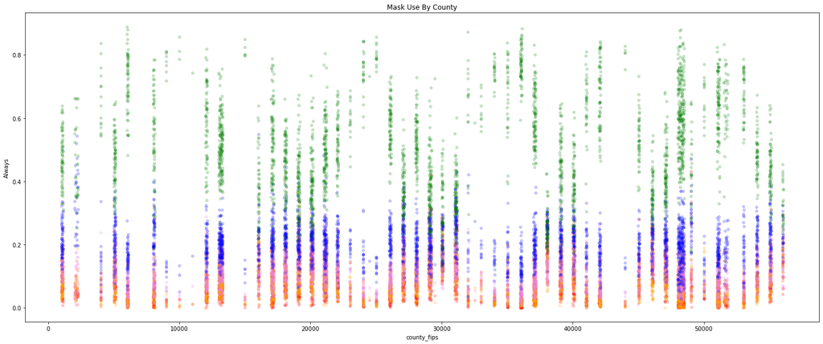

```python
ax1 = mask_df.plot.scatter(x="county_fips", y="Never", c="red", alpha=0.2, figsize=(25,10),)
ax2 = mask_df.plot.scatter(x="county_fips", y="Rarely", c="orange", alpha=0.2, ax=ax1)
ax3 = mask_df.plot.scatter(x="county_fips", y="Sometimes", c="violet", alpha=0.2, ax=ax1)
ax4 = mask_df.plot.scatter(x="county_fips", y="Frequently", c="blue", alpha=0.2, ax=ax1)
ax5 = mask_df.plot.scatter(x="county_fips", y="Always", c="green", alpha=0.2, ax=ax1)
plt.title('Mask Use By County')
```

```python
#Shows mask use by county, each category seperately
#mask_df.plot.scatter(x="county_fips", y="Never", ylim=(0,1), c="red", alpha=0.3, figsize=(10,5))
#mask_df.plot.scatter(x="county_fips", y="Rarely", ylim=(0,1), c="orange", alpha=0.3, figsize=(10,5))
#mask_df.plot.scatter(x="county_fips", y="Sometimes", ylim=(0,1), c="violet", alpha=0.3, figsize=(10,5))
#mask_df.plot.scatter(x="county_fips", y="Frequently", ylim=(0,1), c="blue", alpha=0.3, figsize=(10,5))
#mask_df.plot.scatter(x="county_fips", y="Always", ylim=(0,1), c="green", alpha=0.3, figsize=(10,5))
```

**Graph 2**: Country wide data split up by category. This shows that generally, people who never wear masks make up 20% or less of the county population. There is a greater spread of people who wear masks all the time, ranging from about 20% to above 80%. Keeping in mind, we are not accounting for population size.

```python
mask_county_df['total_votes_divided'] = mask_county_df['total_votes']/2500
mask_county_df['total_votes_divided']
```

```
0       11.1080
1       43.8716
2        4.2072
3        3.8380
4       11.0352
         ...
3137     6.6412
3138     5.8708
3139     3.7608
3140     1.6048
3141     1.4168
Name: total_votes_divided, Length: 3142, dtype: float64
```

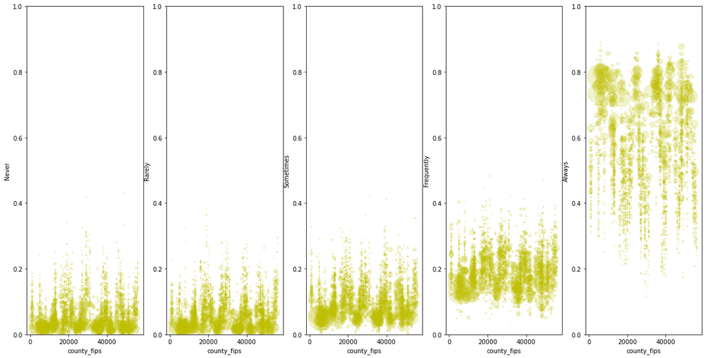

```python
observations = ['Never', 'Rarely', 'Sometimes', 'Frequently', 'Always']
fig, ax = plt.subplots(1, 5, figsize=(20,10))

for i,o in enumerate(observations):
    mask_county_df.plot.scatter(x='county_fips', y=o, ylim=(0,1), s="total_votes_divided", c="y", alpha=0.2, ax=ax[i])
```

To view each state individually...

```python
grouped = mask_county_df.groupby(['state_name'])

#for key, item in grouped:
#    print(grouped.get_group(key))
```

**Graph 3**: These two graphs visualize the the difference between two self reported mask use options, Never and Always, between people who voted Democrat vs. Republican. You may notice they are symmetrical. The per_gop data is the inverse of the per_dem, which accounts for the symmetry.</br> The 'Never wears mask by political party' graph shows the same thing, the more a county votes red, the less likely they are to always wear a mask.

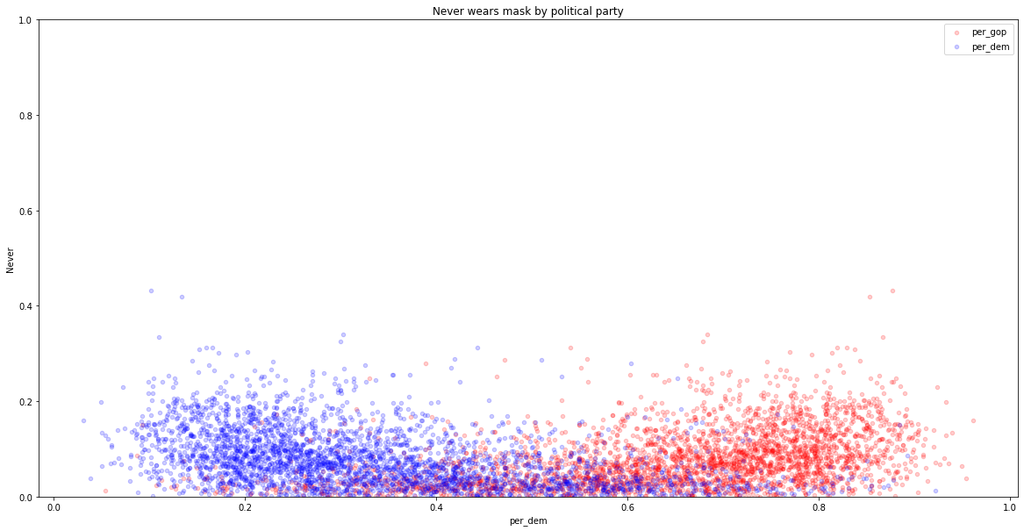

```python
ax1 = mask_county_df.plot.scatter(x="per_gop", y="Never", ylim=(0,1), c="red", alpha=0.2, figsize=(20,10), label="per_gop")
ax2 = mask_county_df.plot.scatter(x="per_dem", y="Never", ylim=(0,1), c="blue", alpha=0.2, ax=ax1, label="per_dem")
plt.title('Never wears mask by political party')
```

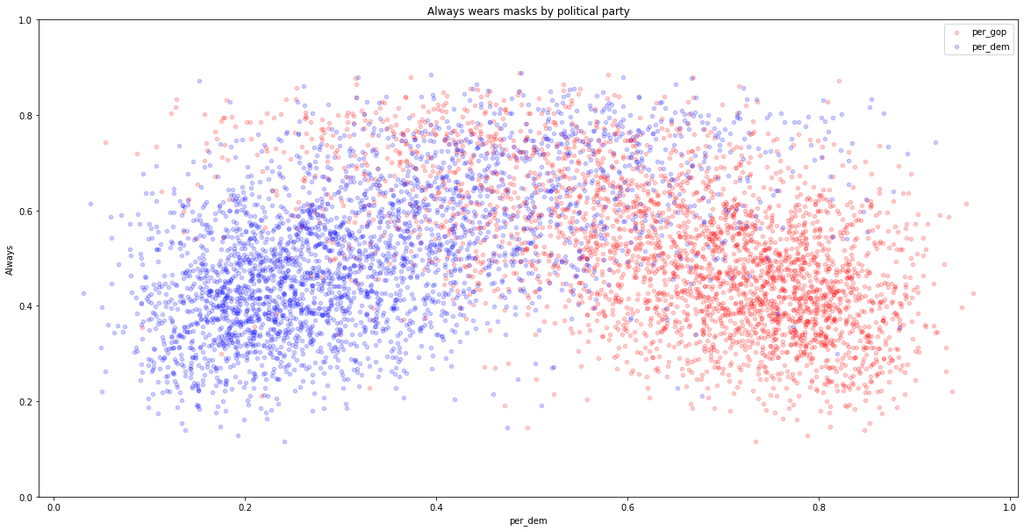

```python
ax1 = mask_county_df.plot.scatter(x="per_gop", y="Always", ylim=(0,1), c="red", alpha=0.2, figsize=(20,10), label="per_gop")
ax2 = mask_county_df.plot.scatter(x="per_dem", y="Always", ylim=(0,1), c="blue", alpha=0.2, ax=ax1, label="per_dem")
plt.title('Always wears masks by political party')
```

### GIS and Data Visualization

For the sake of visualizing our data on a map of the US, let's get the dominant party affiliation by county and the dominant mode of mask wearing by county.

```python
election_test = election_df.set_index('county_fips')
election_test.drop(['state_name', 'county_name', 'total_votes'], axis = 1, inplace = True)
election_test['dominant_party_affiliation'] = election_test.idxmax(axis=1)
```

```python
election_test
```

| county_fips | per_gop | per_dem | dominant_party_affiliation |
| --- | --- | --- | --- |
| 1001 | 0.714368 | 0.270184 | per_gop |
| 1003 | 0.761714 | 0.224090 | per_gop |
| 1005 | 0.534512 | 0.457882 | per_gop |
| 1007 | 0.784263 | 0.206983 | per_gop |
| 1009 | 0.895716 | 0.095694 | per_gop |
| ... | ... | ... | ... |
| 56037 | 0.736554 | 0.230260 | per_gop |
| 56039 | 0.295769 | 0.670982 | per_dem |
| 56041 | 0.797277 | 0.169219 | per_gop |
| 56043 | 0.808824 | 0.162263 | per_gop |
| 56045 | 0.877188 | 0.101637 | per_gop |

3152 rows × 3 columns

```python
mask_test = mask_df.set_index('county_fips')
mask_test['dominant_mask_use'] = mask_test.idxmax(axis=1)
mask_test
```

| county_fips | Never | Rarely | Sometimes | Frequently | Always | dominant_mask_use |
| --- | --- | --- | --- | --- | --- | --- |
| 1001 | 0.053 | 0.074 | 0.134 | 0.295 | 0.444 | Always |
| 1003 | 0.083 | 0.059 | 0.098 | 0.323 | 0.436 | Always |
| 1005 | 0.067 | 0.121 | 0.120 | 0.201 | 0.491 | Always |
| 1007 | 0.020 | 0.034 | 0.096 | 0.278 | 0.572 | Always |
| 1009 | 0.053 | 0.114 | 0.180 | 0.194 | 0.459 | Always |
| ... | ... | ... | ... | ... | ... | ... |
| 56037 | 0.061 | 0.295 | 0.230 | 0.146 | 0.268 | Rarely |
| 56039 | 0.095 | 0.157 | 0.160 | 0.247 | 0.340 | Always |
| 56041 | 0.098 | 0.278 | 0.154 | 0.207 | 0.264 | Rarely |
| 56043 | 0.204 | 0.155 | 0.069 | 0.285 | 0.287 | Always |
| 56045 | 0.142 | 0.129 | 0.148 | 0.207 | 0.374 | Always |

3142 rows × 6 columns

```python
masks_elections = mask_test.merge(election_df, on='county_fips', how='inner')
masks_elections = masks_elections.merge(election_test, on='county_fips', how='inner')
masks_elections
```

|  | county_fips | Never | Rarely | Sometimes | Frequently | Always | dominant_mask_use | state_name | county_name | total_votes | per_gop_x | per_dem_x | per_gop_y | per_dem_y | dominant_party_affiliation |
| --- | --- | --- | --- | --- | --- | --- | --- | --- | --- | --- | --- | --- | --- | --- | --- |
| 0 | 1001 | 0.053 | 0.074 | 0.134 | 0.295 | 0.444 | Always | Alabama | Autauga | 27770 | 0.714368 | 0.270184 | 0.714368 | 0.270184 | per_gop |
| 1 | 1003 | 0.083 | 0.059 | 0.098 | 0.323 | 0.436 | Always | Alabama | Baldwin | 109679 | 0.761714 | 0.224090 | 0.761714 | 0.224090 | per_gop |
| 2 | 1005 | 0.067 | 0.121 | 0.120 | 0.201 | 0.491 | Always | Alabama | Barbour | 10518 | 0.534512 | 0.457882 | 0.534512 | 0.457882 | per_gop |
| 3 | 1007 | 0.020 | 0.034 | 0.096 | 0.278 | 0.572 | Always | Alabama | Bibb | 9595 | 0.784263 | 0.206983 | 0.784263 | 0.206983 | per_gop |
| 4 | 1009 | 0.053 | 0.114 | 0.180 | 0.194 | 0.459 | Always | Alabama | Blount | 27588 | 0.895716 | 0.095694 | 0.895716 | 0.095694 | per_gop |
| ... | ... | ... | ... | ... | ... | ... | ... | ... | ... | ... | ... | ... | ... | ... | ... |
| 3107 | 56037 | 0.061 | 0.295 | 0.230 | 0.146 | 0.268 | Rarely | Wyoming | Sweetwater | 16603 | 0.736554 | 0.230260 | 0.736554 | 0.230260 | per_gop |
| 3108 | 56039 | 0.095 | 0.157 | 0.160 | 0.247 | 0.340 | Always | Wyoming | Teton | 14677 | 0.295769 | 0.670982 | 0.295769 | 0.670982 | per_dem |
| 3109 | 56041 | 0.098 | 0.278 | 0.154 | 0.207 | 0.264 | Rarely | Wyoming | Uinta | 9402 | 0.797277 | 0.169219 | 0.797277 | 0.169219 | per_gop |
| 3110 | 56043 | 0.204 | 0.155 | 0.069 | 0.285 | 0.287 | Always | Wyoming | Washakie | 4012 | 0.808824 | 0.162263 | 0.808824 | 0.162263 | per_gop |
| 3111 | 56045 | 0.142 | 0.129 | 0.148 | 0.207 | 0.374 | Always | Wyoming | Weston | 3542 | 0.877188 | 0.101637 | 0.877188 | 0.101637 | per_gop |

3112 rows × 15 columns

**Graph 4: Geographic Visualizations** In the first choropleth map of dominant party affiliation by county, we are able to see exactly that. We can compare that to the next map, which tracks the dominant mode of mask use by county.

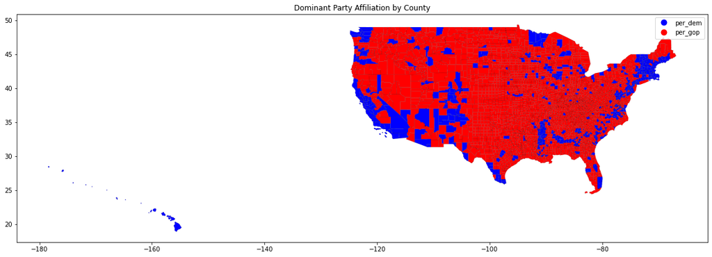

```python
data_map = counties_map.merge(masks_elections, left_on='STATE_COUNTY_FIPS', right_on='county_fips', how='inner')
data_map.plot(data_map['dominant_party_affiliation'], figsize=(20,15), label=data_map['dominant_party_affiliation'], cmap='bwr', edgecolor='black', linewidth=0.1, legend=True)
plt.title('Dominant Party Affiliation by County')
```

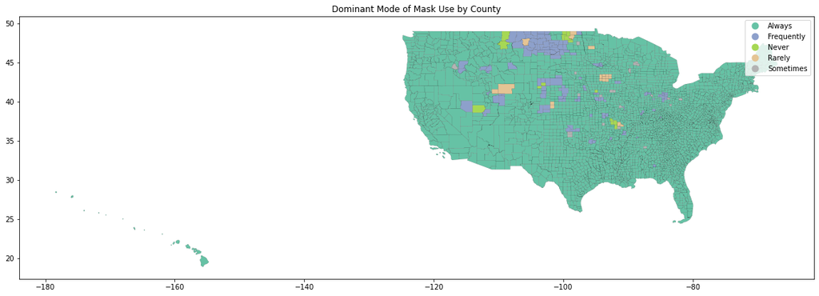

```python
data_map.plot(data_map['dominant_mask_use'], figsize=(20,15), label=data_map['dominant_mask_use'], cmap='Set2', edgecolor='black', linewidth=0.1, legend=True)
plt.title('Dominant Mode of Mask Use by County')
```

**Graph 5: Relationship Strength** Clearly some data was lost, but the data_map dataframe was just for visualization. We can refer to the masks_elections dataframe to make correlation matrices.

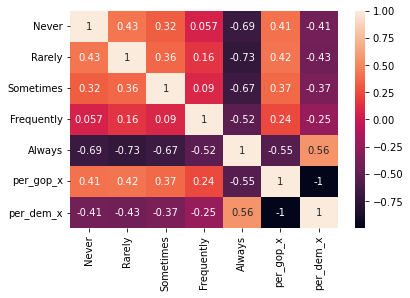

```python
corr_data = masks_elections[['Never', 'Rarely', 'Sometimes', 'Frequently', 'Always', 'per_gop_x', 'per_dem_x']]
sns.heatmap(corr_data.corr(), annot =True )
sns.set(rc = {'figure.figsize':(20,20)})
plt.show()
```

It looks like there is a decent correlation between mask wearing and party affiliation, though it is not clearly represented in our GIS visualization.

```python
masks_elections
```

|  | county_fips | Never | Rarely | Sometimes | Frequently | Always | dominant_mask_use | state_name | county_name | total_votes | per_gop_x | per_dem_x | per_gop_y | per_dem_y | dominant_party_affiliation |
| --- | --- | --- | --- | --- | --- | --- | --- | --- | --- | --- | --- | --- | --- | --- | --- |
| 0 | 1001 | 0.053 | 0.074 | 0.134 | 0.295 | 0.444 | Always | Alabama | Autauga | 27770 | 0.714368 | 0.270184 | 0.714368 | 0.270184 | per_gop |
| 1 | 1003 | 0.083 | 0.059 | 0.098 | 0.323 | 0.436 | Always | Alabama | Baldwin | 109679 | 0.761714 | 0.224090 | 0.761714 | 0.224090 | per_gop |
| 2 | 1005 | 0.067 | 0.121 | 0.120 | 0.201 | 0.491 | Always | Alabama | Barbour | 10518 | 0.534512 | 0.457882 | 0.534512 | 0.457882 | per_gop |
| 3 | 1007 | 0.020 | 0.034 | 0.096 | 0.278 | 0.572 | Always | Alabama | Bibb | 9595 | 0.784263 | 0.206983 | 0.784263 | 0.206983 | per_gop |
| 4 | 1009 | 0.053 | 0.114 | 0.180 | 0.194 | 0.459 | Always | Alabama | Blount | 27588 | 0.895716 | 0.095694 | 0.895716 | 0.095694 | per_gop |
| ... | ... | ... | ... | ... | ... | ... | ... | ... | ... | ... | ... | ... | ... | ... | ... |
| 3107 | 56037 | 0.061 | 0.295 | 0.230 | 0.146 | 0.268 | Rarely | Wyoming | Sweetwater | 16603 | 0.736554 | 0.230260 | 0.736554 | 0.230260 | per_gop |
| 3108 | 56039 | 0.095 | 0.157 | 0.160 | 0.247 | 0.340 | Always | Wyoming | Teton | 14677 | 0.295769 | 0.670982 | 0.295769 | 0.670982 | per_dem |
| 3109 | 56041 | 0.098 | 0.278 | 0.154 | 0.207 | 0.264 | Rarely | Wyoming | Uinta | 9402 | 0.797277 | 0.169219 | 0.797277 | 0.169219 | per_gop |
| 3110 | 56043 | 0.204 | 0.155 | 0.069 | 0.285 | 0.287 | Always | Wyoming | Washakie | 4012 | 0.808824 | 0.162263 | 0.808824 | 0.162263 | per_gop |
| 3111 | 56045 | 0.142 | 0.129 | 0.148 | 0.207 | 0.374 | Always | Wyoming | Weston | 3542 | 0.877188 | 0.101637 | 0.877188 | 0.101637 | per_gop |

3112 rows × 15 columns

```python
county_rates = pd.read_csv("./data/us-counties.csv")
county_rates = county_rates.dropna()
county_rates['fips'] = county_rates['fips'].astype('int64')
county_rates = county_rates[(county_rates['date'] == "2020-07-14")]
county_rates
```

|  | date | county | state | fips | cases | deaths |
| --- | --- | --- | --- | --- | --- | --- |
| 331445 | 2020-07-14 | Autauga | Alabama | 1001 | 746 | 18.0 |
| 331446 | 2020-07-14 | Baldwin | Alabama | 1003 | 1414 | 12.0 |
| 331447 | 2020-07-14 | Barbour | Alabama | 1005 | 428 | 3.0 |
| 331448 | 2020-07-14 | Bibb | Alabama | 1007 | 236 | 2.0 |
| 331449 | 2020-07-14 | Blount | Alabama | 1009 | 366 | 1.0 |
| ... | ... | ... | ... | ... | ... | ... |
| 334633 | 2020-07-14 | Sweetwater | Wyoming | 56037 | 156 | 1.0 |
| 334634 | 2020-07-14 | Teton | Wyoming | 56039 | 164 | 1.0 |
| 334635 | 2020-07-14 | Uinta | Wyoming | 56041 | 208 | 0.0 |
| 334636 | 2020-07-14 | Washakie | Wyoming | 56043 | 42 | 5.0 |
| 334637 | 2020-07-14 | Weston | Wyoming | 56045 | 3 | 0.0 |

3088 rows × 6 columns

```python
t2 = pd.merge(masks_elections, county_rates,  how='left', left_on='county_fips', right_on='fips')
#t2 = t2.fillna(method='ffill')
t2=t2.dropna()
t2['cases'] = t2['cases'].astype('float64')
t2['deaths'] = t2['deaths'].astype('float64')
```

**GIS visualization of the literal number of cases per county. Without percise population rates for 2020 (the Census wasn't conducted in 2020), there's not much else we can do with the cases column.**

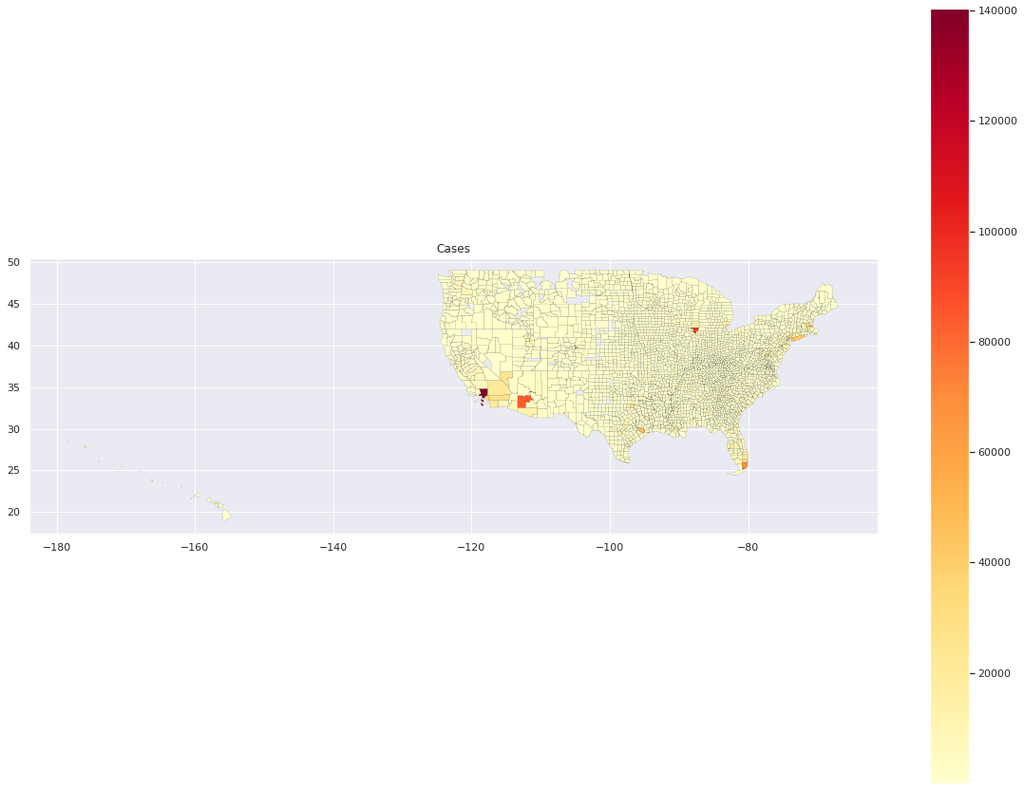

```python
data_map2 = counties_map.merge(t2, left_on='STATE_COUNTY_FIPS', right_on='county_fips', how='inner')
data_map2.plot(data_map2['cases'], figsize=(20,15), label=data_map2['cases'], cmap='YlOrRd', edgecolor='black', linewidth=0.1, legend=True)
plt.title('Cases')
```

### Model Questions

The analysis brings up an important relation that can be described using statistical modeling. We are going to do a statistical analysis to find the correlation between the percent of people that answered 'never' when asked if they wear masks and the county's dominant political affiliation based on the 2020 presidential election.

**Using SKLearn's linear regression model to predict the percentage of registered democrats in a hypothetical county where 100% of people reportedly never wear a mask.**

```python
from sklearn.preprocessing import StandardScaler
from sklearn.linear_model import LinearRegression

X_train = masks_elections[["Always", "Never"]]
y_train = masks_elections["per_dem_x"]

scaler = StandardScaler()
scaler.fit(X_train)
X_train_sc = scaler.transform(X_train)

regressor = LinearRegression()
regressor.fit(X_train_sc, y_train)

x_new = pd.DataFrame()
x_new["Always"] = [0.0]
x_new["Never"] = [1.0]


x_new_sc = scaler.transform(x_new)

regressor.predict(x_new_sc)
```

```
array([-0.07647956])
```

**Predicting the percentage of registered republicans in that same scenario**

```python
X_train = masks_elections[["Always", "Never"]]
y_train = masks_elections["per_gop_x"]

scaler = StandardScaler()
scaler.fit(X_train)
X_train_sc = scaler.transform(X_train)

regressor = LinearRegression()
regressor.fit(X_train_sc, y_train)

x_new = pd.DataFrame()
x_new["Always"] = [0.0]
x_new["Never"] = [1.0]


x_new_sc = scaler.transform(x_new)

regressor.predict(x_new_sc)
```

```
array([1.0602456])
```

**Using SKLearn's linear regression model to predict the percentage of registered democrats in a hypothetical county where 100% of people reportedly always wear a mask.**

```python
X_train = masks_elections[["Always", "Never"]]
y_train = masks_elections["per_dem_x"]

scaler = StandardScaler()
scaler.fit(X_train)
X_train_sc = scaler.transform(X_train)

regressor = LinearRegression()
regressor.fit(X_train_sc, y_train)

x_new = pd.DataFrame()
x_new["Always"] = [1.0]
x_new["Never"] = [0.0]


x_new_sc = scaler.transform(x_new)

regressor.predict(x_new_sc)
```

```
array([0.61243176])
```

**Predicting the percentage of registered republicans in that same scenario**

```python
X_train = masks_elections[["Always", "Never"]]
y_train = masks_elections["per_gop_x"]

scaler = StandardScaler()
scaler.fit(X_train)
X_train_sc = scaler.transform(X_train)

regressor = LinearRegression()
regressor.fit(X_train_sc, y_train)

x_new = pd.DataFrame()
x_new["Always"] = [1.0]
x_new["Never"] = [0.0]


x_new_sc = scaler.transform(x_new)

regressor.predict(x_new_sc)
```

```
array([0.37088089])
```

### Conclusions

Our regression models showed a number of things: 1. There would be no Democrat voters in county where everyone self-reported not wearing a mask. 2. Conversely, there would only be Republican voters in a county where everyone self-reported not wearing a mask. 3. In a hypotheical county where 100% of people reportedly wear a mask, only slightly above 60% of them would be Democratic voters.

We can now answer our initial questions:

1. How does self-reported mask use vary across each county in the United States? Mask use, despite our prediction, is quite even across the US. Around 80% of the population, according to the self reported data, always or frequently wear masks. While this might have changed since the time the data was collected, this does show that masks were not a politicized as we may have been lead to believe.
2. How does self-reported mask use in each county in the US correlate with how they voted in the 2020 presidential election? Mask use was generally accepted by most counties in the US, but our analysis showed that counties with a higher rate of never and rarely wearing mask were more likely to be counties that voted for the Republican presidential candidate in the 2020 election.

Knowing that we are far from the end of the pandemic, it is reassuring knowing that a good portion of the country would mask up when the time calls for it. (The time is now.)